# R Notebook

```r
library(tm)
library(tidytext)
library(tidyverse)
library(DT)
```

```r
urlfile<-'https://raw.githubusercontent.com/rit-public/HappyDB/master/happydb/data/cleaned_hm.csv'
hm_data <- read_csv(urlfile)
```

```r
corpus <- VCorpus(VectorSource(hm_data$cleaned_hm))%>%
  tm_map(content_transformer(tolower))%>%
  tm_map(removePunctuation)%>%
  tm_map(removeNumbers)%>%
  tm_map(removeWords, character(0))%>%
  tm_map(stripWhitespace)
```

```r
stemmed <- tm_map(corpus, stemDocument) %>%
  tidy() %>%
  select(text)
```

```r
dict <- tidy(corpus) %>%
  select(text) %>%
  unnest_tokens(dictionary, text)
```

```r
data("stop_words")
word <- c("happy","ago","yesterday","lot","today","months","month",
                 "happier","happiest","last","week","past","day","time","moment")
stop_words <- stop_words %>%
  bind_rows(mutate(tibble(word), lexicon = "updated"))
```

```r
completed <- stemmed %>%
  mutate(id = row_number()) %>%
  unnest_tokens(stems, text) %>%
  bind_cols(dict) %>%
  anti_join(stop_words, by = c("dictionary" = "word"))
```

```r
completed <- completed %>%
  group_by(stems) %>%
  count(dictionary) %>%
  mutate(word = dictionary[which.max(n)]) %>%
  ungroup() %>%
  select(stems, word) %>%
  distinct() %>%
  right_join(completed) %>%
  select(-stems)
```

```r
completed <- completed %>%
  group_by(id) %>%
  summarise(text = str_c(word, collapse = " ")) %>%
  ungroup()
```

```r
hm_data <- hm_data %>%
  mutate(id = row_number()) %>%
  inner_join(completed)
```

```r
library(tidyverse)
library(tidytext)
library(DT)
library(scales)
library(wordcloud2)
library(gridExtra)
library(ngram)
library(shiny)
```

```r
urlfile<-'https://raw.githubusercontent.com/rit-public/HappyDB/master/happydb/data/demographic.csv'
demo_data <- read_csv(urlfile)
```

```r
hm_data <- hm_data %>%
  inner_join(demo_data, by = "wid") %>%
  select(wid,
         original_hm,
         gender,
         marital,
         parenthood,
         reflection_period,
         age,
         country,
         ground_truth_category,
         predicted_category,
         text) %>%
  mutate(count = sapply(hm_data$text, wordcount)) %>%
  filter(gender %in% c("m", "f")) %>%
  filter(marital %in% c("single", "married")) %>%
  filter(parenthood %in% c("n", "y")) %>%
  filter(reflection_period %in% c("24h", "3m")) %>%
  mutate(reflection_period = fct_recode(reflection_period,
                                        months_3 = "3m", hours_24 = "24h"))
```

```r
nrow(hm_data)
```

```
[1] 94508
```

```r
length(unique(hm_data$wid))
```

```
[1] 9972
```

# Part 1

# Part 2

Are sources of happiness influenced largely by time intervals? It is reasonable to expect that people tend to recall big events or impressive moments in 3-month interval, whereas detailed events and daily moments are more likely to appear in 24-hour interval.

We first use predicted_category that categorized different happy moments to see if there is a significant difference in categories of happiness between 3-month and 24-hour time interval.

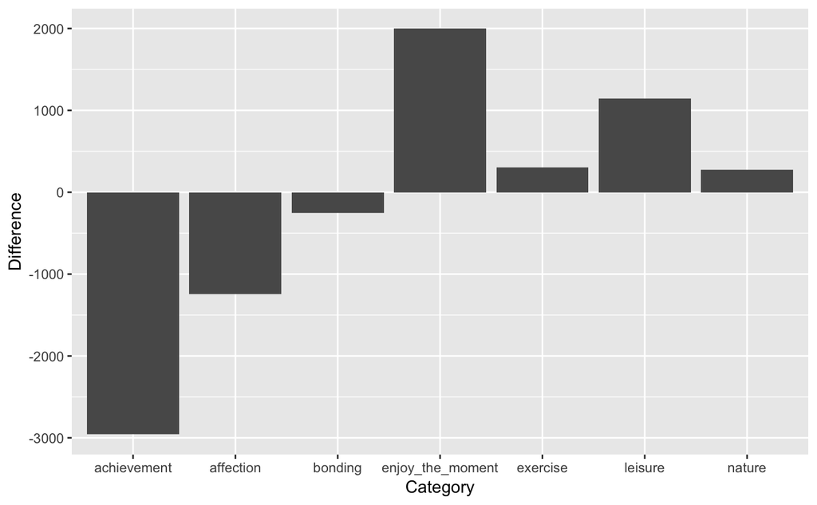

```r
library(ggplot2)
hm_data_3m<-hm_data[hm_data$reflection_period=="months_3",]
hm_data_24h<-hm_data[hm_data$reflection_period=="hours_24",]
dtframe<-data.frame(table(hm_data_24h$predicted_category)-table(hm_data_3m$predicted_category))
colnames(dtframe)<-c("Category","Difference")
ggplot(dtframe,aes(x=Category,y=Difference))+
  geom_bar(stat="identity")
```

As we can see from the above histogram, people talk more about achievement and affection in 3-month interval, whereas enjoy the moent and leisure appears more in 24-hour interval. This illustrates the point made in the beginning of this part that achievemnet and affection are long-last memory and sentiment, whereas moment of life and leisure time are transitory.

Now let us look at frequecy of specific words for 24-hour and 3-month time intervals.

```r
hm_data_24h_bigram <- hm_data_24h %>%
  unnest_tokens(bigram, text, token = "ngrams", n = 2) %>%
  count(bigram,sort = TRUE)
head(hm_data_24h_bigram,10)
```

| bigram | n |
| --- | --- |
| NA | 1464 |
| video game | 438 |
| watched movie | 309 |
| ice cream | 294 |
| played video | 197 |
| played game | 179 |
| talked friend | 161 |
| watched favorite | 155 |
| met friend | 150 |
| read book | 150 |

```r
hm_data_3m_bigram <- hm_data_3m %>%
  unnest_tokens(bigram, text, token = "ngrams", n = 2) %>%
  count(bigram,sort = TRUE)
head(hm_data_3m_bigram,10)
```

| bigram | n |
| --- | --- |
| NA | 1359 |
| birthday party | 311 |
| video game | 280 |
| ice cream | 211 |
| bought car | 179 |
| celebrated birthday | 176 |
| watched movie | 173 |
| friend birthday | 163 |
| friend mine | 159 |
| family friend | 138 |

We can see from that in 24-hour period, people feel happy due to everyday events such as playing video game, watching movie, eating ice cream, talking to friends. On the other hand, in 3-month period, their happiness come from impressive big events like birthday party and buying a car.

This result again answers the question in the very beginning of this section that sources of happiness depends on length of time period.

# Part 3

Next we want to investigate the relationship between happiness and gender. Does the causes of happiness differ between male and female?

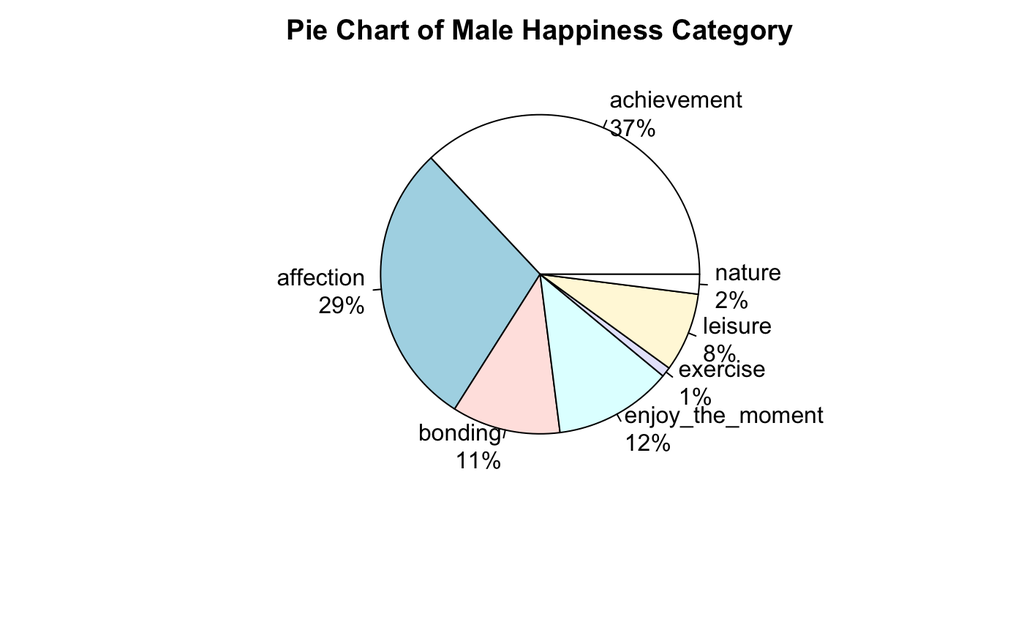

```r
hm_data_m<-hm_data[hm_data$gender=="m",]
hm_data_f<-hm_data[hm_data$gender=="f",]
tablem<-round(table(hm_data_m$predicted_category)/nrow(hm_data_m)*100)
lbls <- paste(names(tablem), "\n", tablem, sep="")
lbls<- paste(lbls,"%",sep="")
pie(tablem, labels = lbls,
   main="Pie Chart of Male Happiness Category")
```

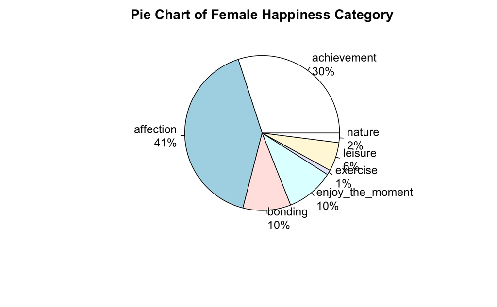

```r
tablef<-round(table(hm_data_f$predicted_category)/nrow(hm_data_f)*100)
lblsf <- paste(names(tablef), "\n", tablef, sep="")
lblsf<- paste(lblsf,"%",sep="")
pie(tablef, labels = lblsf,
   main="Pie Chart of Female Happiness Category")
```

From an overall pie chart of happiness category, we see that female talk a lot more about affection (12% higher) while male talk more about achievement (7% higher).

```r
hm_data_m_bigram <- hm_data_m %>%
  unnest_tokens(bigram, text, token = "ngrams", n = 2) %>%
  count(bigram,sort = TRUE)
head(hm_data_m_bigram,10)
```

| bigram | n |
| --- | --- |
| NA | 1767 |
| video game | 588 |
| watched movie | 320 |
| birthday party | 286 |
| ice cream | 274 |
| played video | 223 |
| friend mine | 214 |
| met friend | 200 |
| played game | 186 |
| friend birthday | 173 |

```r
hm_data_f_bigram <- hm_data_f %>%
  unnest_tokens(bigram, text, token = "ngrams", n = 2) %>%
  count(bigram,sort = TRUE)
head(hm_data_f_bigram,10)
```

| bigram | n |
| --- | --- |
| NA | 1056 |
| ice cream | 231 |
| birthday party | 162 |
| watched movie | 162 |
| video game | 130 |
| read book | 127 |
| family friend | 115 |
| played game | 115 |
| grocery store | 114 |
| bought car | 101 |

We can conclude from the above list that playing video game(“video game”,“played video”,“played game”) ranks at the top of bigram list when males recall their happy moment, whereas ice cream rank at the top at female’s list. Besides, both “watch movie” and “birthday party” rank as top words among both male’s and female’s list.